# EB Statistics Practicals Guideline - Practical 2

author: Francoise Cabada-Blanco

Last updated: 18/03/2022

In this second computer lab, you will learn how to use R to do data screening and test hypotheses about differences between two groups. Specifically, you will learn how to perform the following:

**1.** Create a dataframe from a csv file using the console

**2.** Plot a histogram and a Q-Q plot to explore the distribution of the data

**3.** Test for non-normality

**4.** Test for homogeneity of variances

**5.** Conduct a t-test for independent samples

**6.** Conduct a Mann-Whitney test for independent samples

The activities are presented in steps. For each step you are expected to answer one or two questions. Open the Answers word file to write your answers and copy your plots.

The code to perform all calculations is provided below. Read carefully the instructions and remember to run each line of code one by one in sequential order.

Remember that the first thing you need to do is check that your working directory is where you intend it to be. That would be on your **Practical 2** subfolder. You can check this by seeing if the files on the **Files** tab in RStudio are the ones in your **Practical 2** folder. If they are not, you can change the working directory by clicking in *Session* at the top menu, then *Set working directory* and lastly, *Choose directory*. This will prompt a window where you can Browse to the correct **Practical 2** folder.

## **STEP 1**

### Create a dataframe from a csv file using the console

The second cause of the increased in deforestation within the panamazonic watershed is illegal gold mining. Besides deforestation, one of the main impacts of illegal gold mining is the pollution of freshwater systems caused by mercury. Mercury is used to amalgamate gold and once used, it is directly thrown to creeks and rivers. The heavy metal can be bioaccumulated within the trophic web, causing serious damage to public health and disrupting whole ecosystems.

In an investigation of the possible effects of mercury on wild freshwater fishes, some Rosy barbs (*Puntius conchonius*) were exposed to 181 smg/l of mercury chloride and some were not (control treatment). After 48 h of exposure, the activity of the enzyme aspartate aminotransferase (AAT) was measure in the liver of all fishes in nM/$\mu$g/min. The researchers want to know if exposure to mercury affects the activity of the enzyme AAT.

The data for the enzyme activity is stored on a comma separated value file named aat.csv within the **Practical 2** subfolder. Open the file using the code below

```r
##############  Open a csv file from the console ###################

# open the file in a object named "hg"
aat<-read.csv("aat.csv", header = TRUE, stringsAsFactors = TRUE)

# inspect the type of object
class(aat)
```

> **Question 1**: How many cases and how many variables does the dataset has?

> **Question 1.1** : Specify the type of variable and the scale of measurement for each, indicating which one is the explanatory or independent variable and which is the response or dependent variable

> **Question 1.2** : What are the groups you would like to compare?

As you progress in your scientific career, you will have to work with many different types of data that will be arranged in many different ways. The dataset you uploaded is in an horizontal arrangement. This is more similar to the tables you have been building to present your results in.

We will also upload a vertical one. The purpose of using also a vertical arrangement is because as you move forward, this is the type of arrangement that most test require the data to be input in. That is in R, but also in other software like SPSS.

Use the code below to open the aat_vet.csv file where the data is arranged vertically

```r
##############  Open a csv file from the console ###################

# open the file in a object named "hg"
aat_vertical<-read.csv("aat_vert.csv", header = TRUE, stringsAsFactors = TRUE)

# inspect the type of object
class(aat)
```

## **STEP 2**

### Perform summary statistics and describe the data

You already learned how to do descriptive statistics with R. The code below will provide you with the measures of location and spread that you need to write as a short narrative describing the data as shown during the Q&As and the previous practical.

```r
################ Summary Statistics ###########

# get the mean, median and quartiles along with the range, maximum and minumum values
summary(aat)

# get the standard deviation for each group
sd(aat$aat_control)

sd(aat$aat_hg)
```

> **Question 2**: Write a short narrative describing the data. Remember to include the basic information that a reader needs for they to have an idea of the data obtained by the researchers.

## **STEP 3**

### Plot a histogram

Now, to complement that description you are going to plot a histogram for each group. To plot a histogram we use the function *hist*. You can learn what the function does by typing *hist* into the search box in the *Help* tab or by typing *hist?* in the console.

```r
################ PLOT A HISTOGRAM ###########

# for the control fishes
hist_control<-hist(aat$aat_control,
            xlab= "nM/mg/min",
            main= "AAT activity in control group",
            col="skyblue")

# for the fishes exposed to Hg
hist_control<-hist(aat$aat_hg,
            xlab= "nM/mg/min",
            main= "AAT activity in Hg exposed",
            col="darkred")
```

> **Question 3**: Copy and paste the histograms into your narrative and remember to reference the figure and include a caption.

## **STEP 4**

### Hypothesis testing

to provide an answer to the research question *Does exposure to mercury affects the activity of the enzyme AAT?*, you need to test whether there is a significant difference (both statistically and biologically) in the activity of AAT between fishes that were exposed to mercury and those that were not.

The following steps will walk you through how to evaluate evaluate if that difference between the means of both groups or treatments is indeed statistically significant.

## **STEP 4.1**

### The null hypothesis

As we have seen in the pre-recorded lectures and the Q&A drop-ins, the first step in hypothesis testing is defining the hypothesis we are going to test against.

> **Question 4**: Write the logical hypothesis and its null equivalent (logical null hypothesis) in an IF-THEN statement

> **Question 4.1**: Write the null statistical hypothesis

## **STEP 4.2**

### Data screening

You now need to screen your data to find out if the data meets the assumption of the test and, based on this, select the test that is appropriate.

#### Testing for non-normality

First we test the null hypothesis that the data comes from a normal distribution. Remember that in the test for normality, the null hypothesis is counterintuitive and failing to accept it, means that there is strong evidence for non-normality.

> **Ho**: data comes from a population with normal distribution

> **Hi**: data does not come from a population with normal distribution

Use the code below to test for the normality of the data for both groups. We are setting a confidence level of 95$\%$, therefore, $\alpha$=0.05.

```r
################### Test for non-normality ######################

# use the Shapiro-Wilks test with the control group
shapiro.test(aat$aat_control)

# use the Shapiro-Wilks test with the mercury-exposed group
shapiro.test(aat$aat_hg)
```

If the p-value is greater than $\alpha$ we fail to reject **Ho**

> **Question 4.2**: Is the data from both groups normally distributed? Write your results in narrative form. Remember to include the value of the test statistic and the p-value.

To illustrate your results, you will make two Q-Q plots, one per group or treatment. These plots can also help you explore if your data comes from a population that has a normal distribution. Remember that a statistical test can have weak power or not be robust enough and these plots are really useful to detect if we need to use a more robust test.

Use the code below to plot two Q-Q plots simultaneusly.

```r
################### QQ-plots ######################

# specify that we want the plots together.Build an empty table
# to put the plots in. So, 1 row and 2 columns
par(mfrow=c(1,2))

# create Q-Q plot for the control group
qqnorm(aat$aat_control,main="Control")
qqline(aat$aat_control)

# create Q-Q plot for the control group
qqnorm(aat$aat_hg,main="Hg")
qqline(aat$aat_hg)
```

> Copy and paste the plots in your answer file and remember to reference them in the narrative where you are describing the results for the normality test.

#### Testing for homogeneity of variances

The second assumption of most parametric statistical test, and many non-parametric ones, is that the variances of the groups are homogeneous. To find out if they are, you will perform a Levene test.

The null and alternative hypothesis for a Levene’s test are:

> **Ho**: the variances are homogeneous

> **Hi**: the variances are heterogeneous

Use the code below to perform a Levene test

```r
#################### Test for homoscesdasticity ####################

# first we install the package where the function is
install.packages("car")

# then we load the package from he library
library(car)

# run the Levene test
leveneTest(aat_activity ~ treatment, data= aat_vertical)
```

> **Question 4.3**: Are the variances homogeneous? Write your results in narrative form. Remember to include the value of the test statistic, degrees of freedom and the p-value.

#### Using transformations to deal with non-normality and heteroscedasticity

As explained in the pre-recorded lectures and Moodle books, you can transform your response variable to deal make your transformed data normally distributed and/or homoscedastic. With the code below you can transform the data and run the test again to see if the transformation helped.

```r
#################### transforming data  ####################

# create a new variable or column in the data that is the logarithm of the AAT activity
aat_vertical$log_trans<-log(aat_vertical$aat_activity)

# run the Levene test
leveneTest(log_trans ~ treatment, data= aat_vertical)
```

Now that we know the transformed has homogeneous variances, we proceed to perform a t-test.

## **STEP 4.3**

### Students’ t-test

Use the code below to perform a t-test for independent samples, using the Welch test statistic.

```r
#################### Independent samples t-test  ####################

# perform the t-test
t.test(log_trans ~ treatment, data= aat_vertical)
```

See Fig. 1 for the meaning of the test output

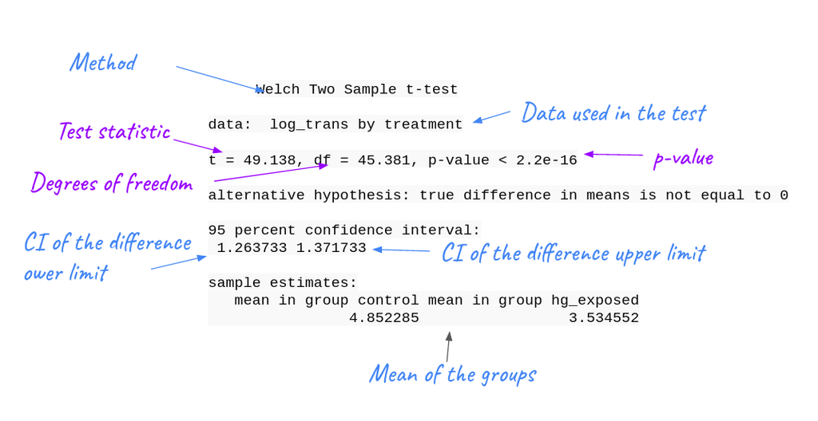

Figure 1. How to read the output of a t-test

> **Question 4.4**: Do you failed to accept or to reject your Null Hypothesis? Write the results of your t-test in a narrative form and remember to include the value of the test statistic, degrees of freedom and p-value.

type *t.test* in the help search box of RStudio and read the arguments and their default setting.

> **Question 4.5**: What argument(s) would you change in the t.test function and how if you would like to perform a t-test for paired samples?

> **Question 4.6**: What argument(s) would you change in the t.test function and how if you would like to test a null hypothesis like this one: Ho $$1 >$$2?

To illustrate the difference in means, now you should add a boxplot with both groups to your results. Use the code below to build the plot

```r
#################### Boxplot with more than 1 variable  ####################

# boxplot by level of one factor
plot(aat_activity ~ treatment, data= aat_vertical, col= c("orange","darkorange1"))

# add points
stripchart(aat_activity ~ treatment, data= aat_vertical,
           method = "jitter",
           pch = 19,
           col = 1,
           vertical = TRUE,
           add = TRUE)
```

You now know how to perform a t-test for both independent and paired samples. However, to learn how to do a Mann-Whitney test, let us assume the enzyme AAT activity failed the test for normality.

Use the code below to learn how to do a non-parametric test for the null hypothesis of no differences between groups.

```r
#################### Mann-Whitney U test  ####################

# Mann-Whitney U test
wilcox.test(aat_activity ~ treatment, data= aat_vertical)
```